# Workshop Survey Project

Sarah Swiston

2026-04-26

# Pre-Workshop Questions

Question 1: What is your current career stage?

1. Undergraduate student
2. Master’s student
3. Ph.D. student
4. Postdoctoral researcher
5. Faculty
6. Non-faculty professional
7. Other (specify)

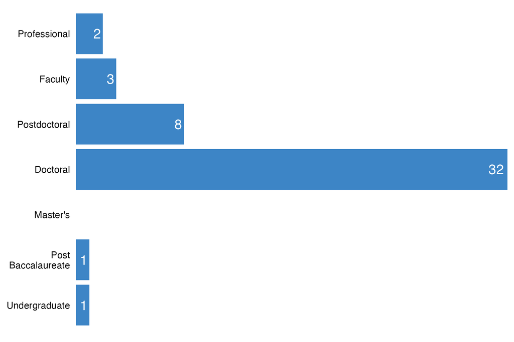

```
## N =  47
```

Question 2: What were your initial goals when you applied for this workshop? Check all that apply.

1. Learn about the kinds of questions that phylogenetic methods of historical biogeography can answer
2. Learn more about different types of models
3. Learn more about software tools
4. Try out coding a model with the help of workshop facilitators
5. Decide whether to do future research using phylogenetic methods of historical biogeography
6. Discuss research ideas with workshop facilitators and other participants
7. Network with other researchers
8. Add the workshop to a resume or CV
9. I did not have any goals when I applies for this workshop
10. Other (specify)

Finding: According to exact binomial tests performed on each category, most participants reported that they were interested in learning about models, software tools, and questions before the workshop.

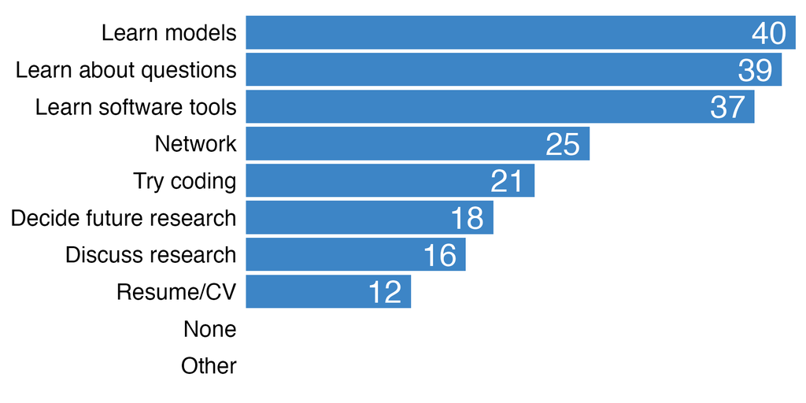

```
##  N =  47
##  Exact binomial test
##  Models:     0.85  | p =  5.354559e-07
##  Software:   0.79  | p =  4.924439e-05
##  Questions:  0.83  | p =  2.769811e-06
##  Decide:     0.38
```

Question 3: Please rate your experience with the following topics and tools:

1. Probability and statistics
2. Molecular phylogenetics
3. Divergence time estimation
4. Biogeographic models
5. Bayesian models
6. Markov chain Monte Carlo
7. Unix command line
8. RevBayes

Options: Unfamiliar, somewhat familiar, competent, highly competent, expert

Finding: According to an exact binomial test comparing the combined “somewhat familiar” and “competent” categories with all other categories, most participants were either “somewhat familiar” or “competent” across topics (excluding RevBayes). According to an exact binomial test comparing the combined “highly competent” and “expert” categories with all other categories, few participants rated themselves as highly competent or expert across topics (excluding RevBayes). According to the exact Wilcoxon signed rank test comparing the responses for the RevBayes topic to the second-most unfamiliar topic (biogeographic models), the most unfamiliar topic was RevBayes.

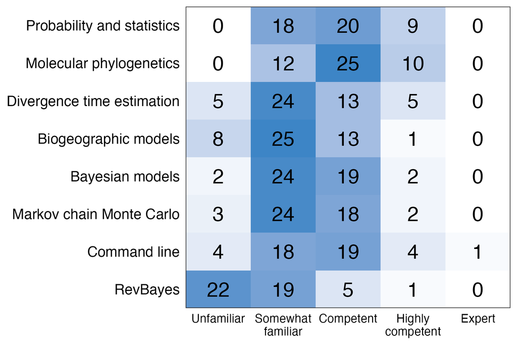

```
##  N =  47
##  Exact binomial test
##  Somewhat familiar & competent:  0.83  | p =  1.711603e-35
##  Highly competent & expert:       0.1  | p =  4.122718e-53
##  Exact Wilcoxon signed rank test
##  Unfamiliar models vs. RevBayes:       | p =  0.0003309771
##  Mean RevBayes familiarity:      1.68
```

Question 4: During your time as a researcher, how often have the following events occurred?

- I wanted to use a research method, but stopped because the *software* was too difficult to use.
- I used a research method even though the *software* was difficult to use.
- I wanted to use a research method, but stopped because the *programming* was too difficult.
- I used a research method even though the *programming* was difficult.
- I wanted to use a research method, but stopped because the *statistical analysis* was too difficult.
- I used a research method even though the *statistical analysis* was difficult.
- I wanted to use a research method, but stopped because the *model* was too difficult to understand.
- I used a research method even though the *model* was difficult to understand.

Options: Never, Rarely, Sometimes, Often, Very often

Finding: According to exact Wilcoxon signed rank tests (both pairwise for each challenge and overall), participants indicated that they were significantly more likely to continue research despite a variety of challenges than to stop due to those challenges.

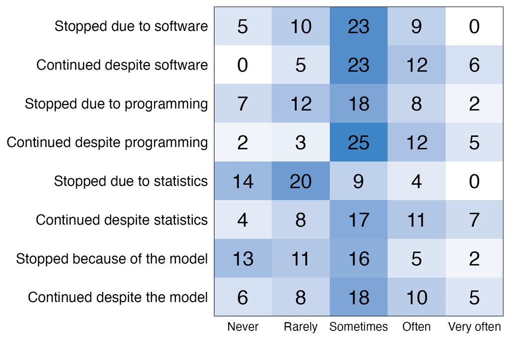

```
##  N =  47
##  Exact Wilcoxon signed rank test
##  Software:    p =  0.00135183
##  Programming: p =  0.002792332
##  Statistics:  p =  2.350658e-06
##  Model:       p =  0.007711541
##  Total:       p =  3.994062e-10
##  Stop mean response:      2.48
##  Continue mean response:  3.23
```

Question 5: Do you plan to use phylogenetic methods of historical biogeography in your own research?

- Yes
- No
- Unsure

If so, when do you plan to start using them?

- I already use these models
- Within the next 3 months
- Between 3 and 6 months
- Between 6 months and 1 year
- After 1 year

How do you plan to apply these methods in your own research?

Finding: According to the exact binomial test, most participants plan to use phylogenetic methods of historical biogeography before the workshop.

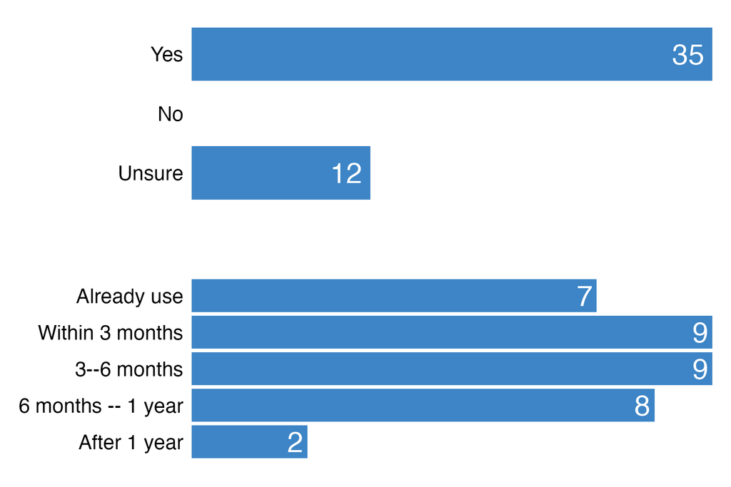

```
##  N =  47
##  Exact binomial test
##  Yes:  0.74  | p =  0.0005442691
```

# Post-Workshop Questions

Question 1: Did this workshop meet your expectation? Why or why not?

Coded Responses:

- Did not meet expectations
- Partly met expectations
- Met expectations
- Exceeded expectations

Finding: According to the exact binomial test on the combined number of participants who indicated that their expectations were met and exceeded, participants felt that their expectations for the workshop were met or exceeded.

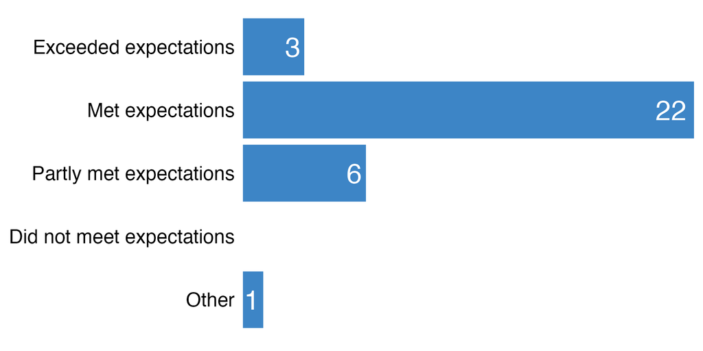

```
##  N =  32
##  Exact binomial test
##  Met & exceeded:  0.78  | p =  0.001051201
```

Question 2: For each of the following topics and tools, please indicate how your level of confidence in your ability to use the tool has *changed* after engaging in the workshop.

1. Probability and statistics
2. Molecular phylogenetics
3. Divergence time estimation
4. Biogeographic models
5. Bayesian models
6. Markov chain Monte Carlo
7. Unix command line
8. RevBayes

Options: Much less confident, less confident, about the same, more confident, much more confident

Finding: According to exact binomial tests for each topic on the combined “more confident” and “much more confident” response categories compared to all other response categories, for RevBayes and biogeographic models (the topics with the least prior experience and the most prevalent participant goals, not statistically tested), confidence significantly improved.

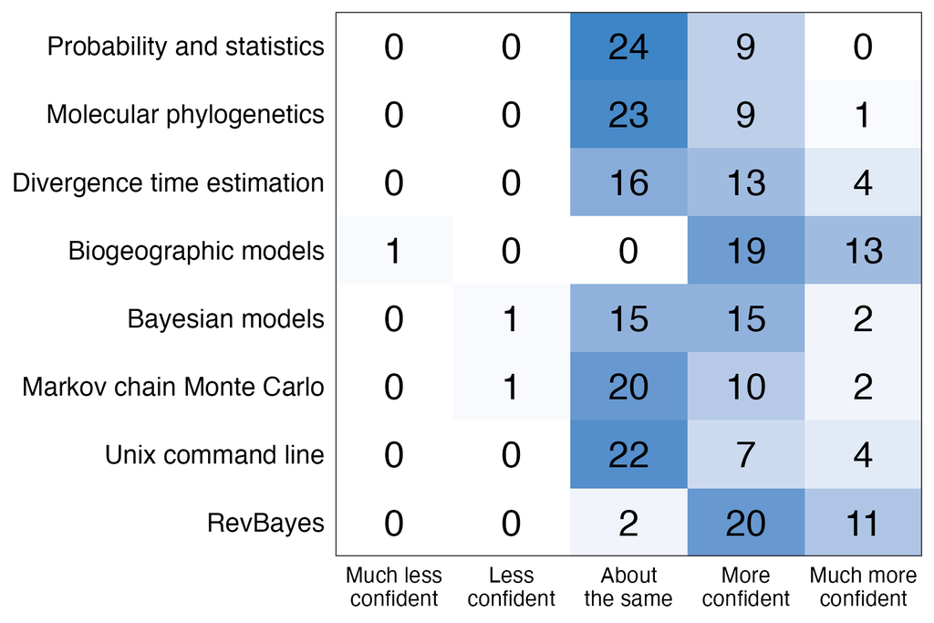

```
##  N =  33
##  Exact binomial test
##  Biogeographic models:  4.3  | p =  3.958121e-09
##  RevBayes:             4.27  | p =  6.542541e-08
```

For individuals who completed both the pre-workshop survey and the post-workshop survey, we also compared confidence improvement to initial experience level. Across topics, it appears that individuals with less experience had greater confidence improvements (no statistical tests performed).

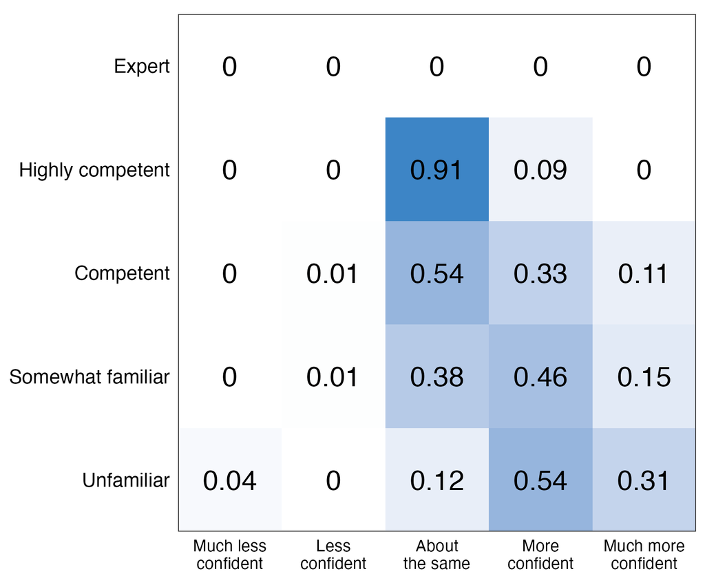

Question 3: Of the tools or skills addressed in the workshop, what is one thing you could implement in your research relatively easily?

Question 4: How likely are you to use skills or tools that you *acquired during the workshop* in the future? Why?

Options: Very unlikely, unlikely, neutral, likely, very likely

Finding: According to the exact binomial test on the combined “likely” and “very likely” response categories compared to other response categories, most participants indicated that they would use skills or tools acquired during the workshop.

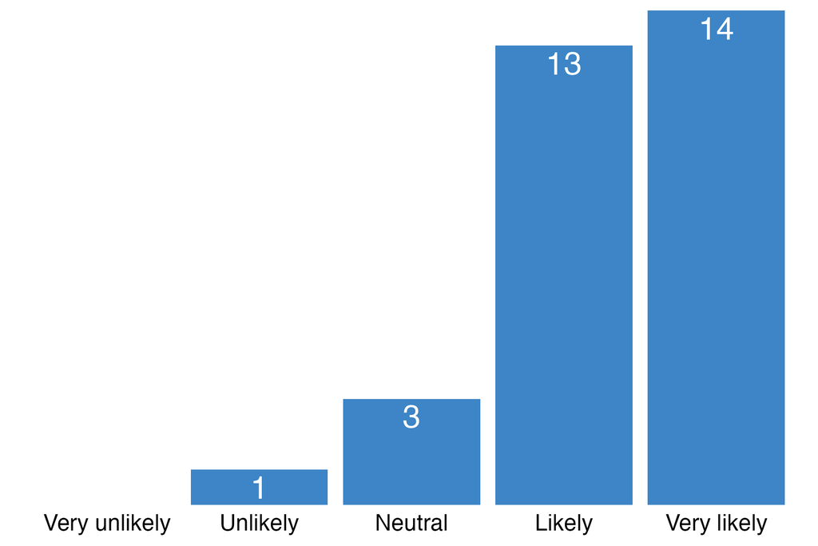

```
##  N =  31
##  Exact binomial test
##  Likely & very likely:  0.87  | p =  1.697661e-05
```

Question 5: If you plan to use skills or tools acquired during the workshop, which one(s) do you plan to use?

Question 6: Are you more or less likely to engage with phylogenetic models of historical biogeography *after having taken the workshop* (compared to how you felt before)? Why?

Options: Much less likely, less likely, about the same, more likely, much more likely

Finding: According to the exact binomial test comparing the combined “more likely” and “much more likely” response categories to all other response categories, participants considered themselves more likely to engage with these models after having taken the workshop.

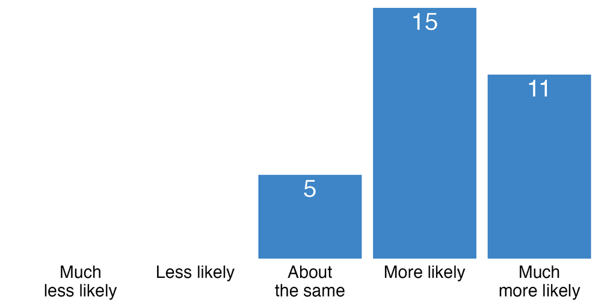

```
##  N =  31
##  Exact binomial test
##  More & much more likely:        0.84  | p =  9.609759e-05
##  Mean change:                    4.19
##  Proportion referencing models:  0.82
```

Question 7: How helpful were these specific activities to your learning?

1. Lecture-style presentations
2. Group discussions
3. Coding by yourself
4. “Coding along” with the instructor
5. Workshopping research ideas

Options: Very unhelpful, unhelpful, neutral, helpful, very helpful, N/A

Finding: According to the exact Wilcoxon ranked sign test comparing the “lecture-style presentation” category to all other categories, participants preferred lectures over other activities. However, PLC was still perceived as helpful according to the exact binomial test.

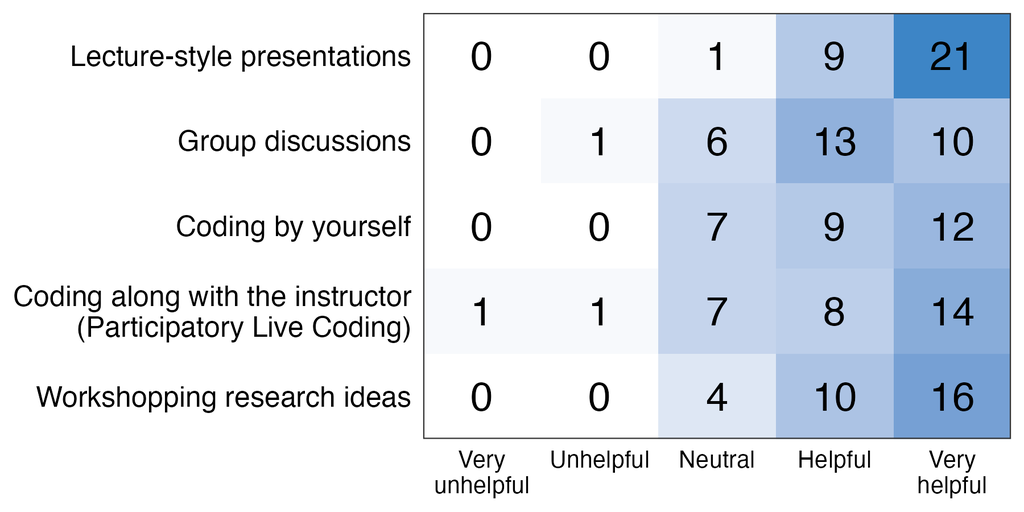

```
##  N =  31
##  Exact Wilcoxon signed rank test
##  Lecture vs. other:                  p =  0.002646135
##  Exact binomial test
##  PLC:                        0.71  | p =  0.01472469
##  Lecture mean response:      4.65
##  Non-lecture mean response:  4.25
##  PLC mean response:          4.06
```

Question 8: Did you encounter any challenges during the workshop, and how did you handle them?

**The term “participatory live coding” refers to activities where the instructor was typing code that everyone could see, and you “coded along” on your own computer.**

Question 9: Do you think the *participatory live coding* activity will make it easier to implement phylogenetic models of historical biogeography in the future?

Options: Much less easy, less easy, about the same, more easy, much more easy, I did not participate in this activity

Finding: According to the exact binomial test comparing the combined “more easy” and “much more easy” categories to all other categories, participants did not indicate that participatory live coding would make it easier to implement the models in the future.

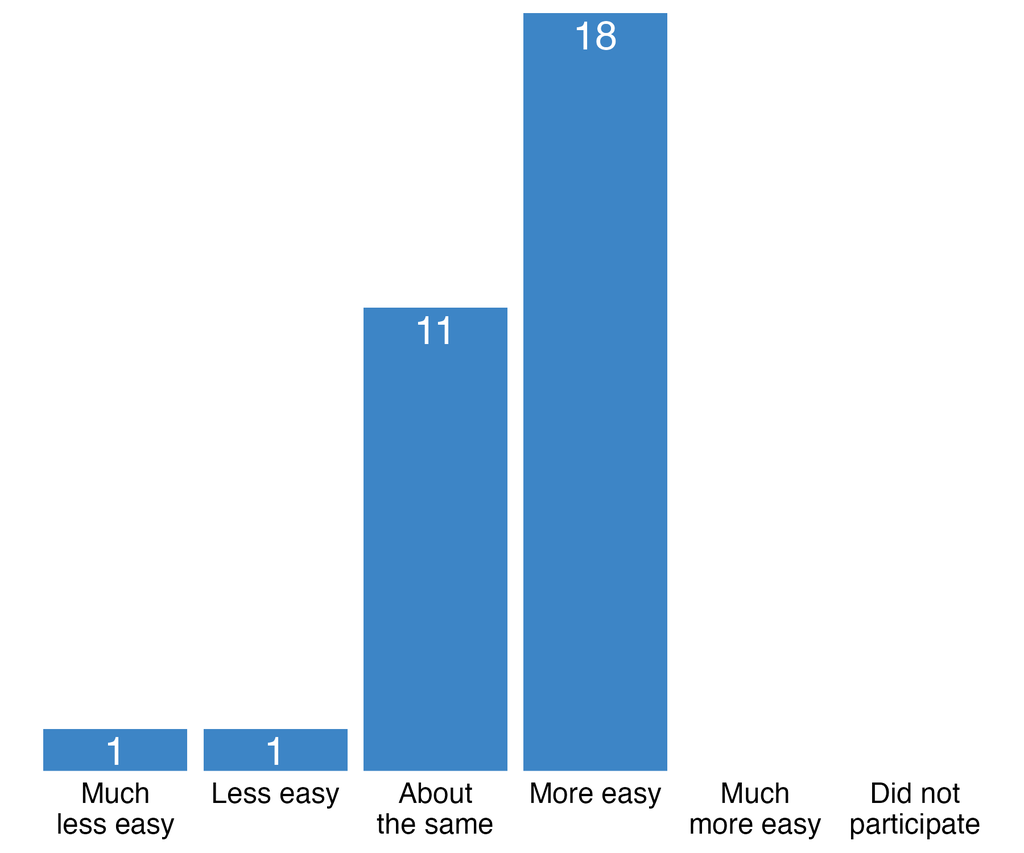

```
##  N =  31
##  Exact binomial test
##  More & much more easy:  0.58  | p =  0.2365648
##  Mean response:          3.48
```

Question 10: Do you think the *participatory live coding* activity made you more or less likely to engage with phylogenetic models of historical biogeography?

Options: Much less likely, less likely, about the same, more likely, much more likely, I did not participate in this activity

Finding: According to the exact binomial test comparing the combined “more likely” and “much more likely” categories to all other categories, participants did not indicate that participatory live coding would make them more likely to implement the models in the future.

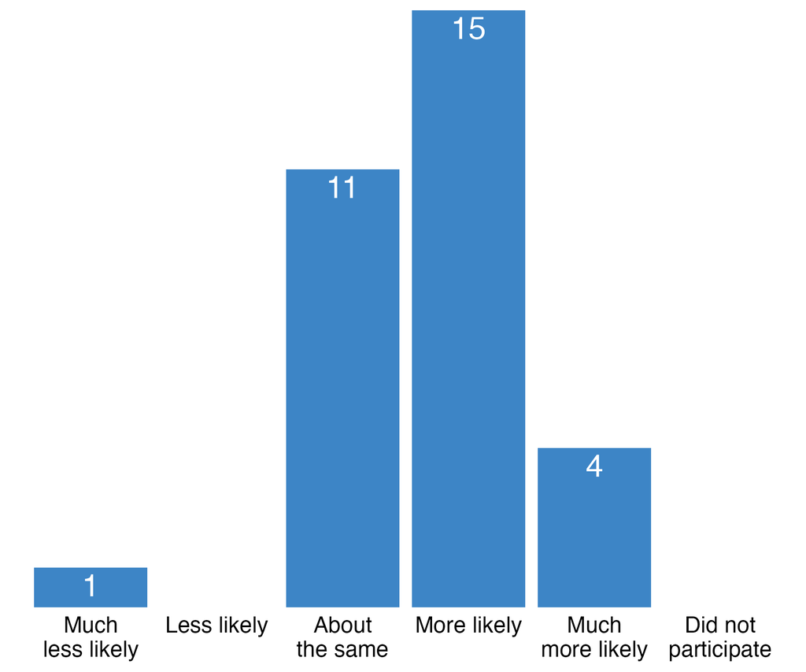

```
##  N =  31
##  Exact binomial test
##  More & much more likely:  0.61  | p =  0.1405208
##  Mean response:            3.68
```